## Assignment 3

Derek Rouch

LLO 8200

Introduction to Data Science

September 5, 2019

#### Setting up R

To begin, I cleared my Global Environment and retrieved the necessary libraries: `knitr`, `tidyverse`, `plotly`, and `Metrics`.

```r
## Clear environment
rm(list=ls())

## Get libraries
library(knitr)
knitr::opts_chunk$set(echo = TRUE)
library(tidyverse)
```

```r
library(plotly)
library(Metrics)

## Set working director
setwd("~/Documents/GitHub/data-science")
```

Then, I loaded the `attrition.Rdata` dataset.

```r
## Load in the attrition dataset
load("~/Documents/GitHub/data-science/attrition.Rdata")
```

#### 1) Create a graph that shows the distribution of monthly income.

Monthly income is a continuous variables, so I created a histogram below.

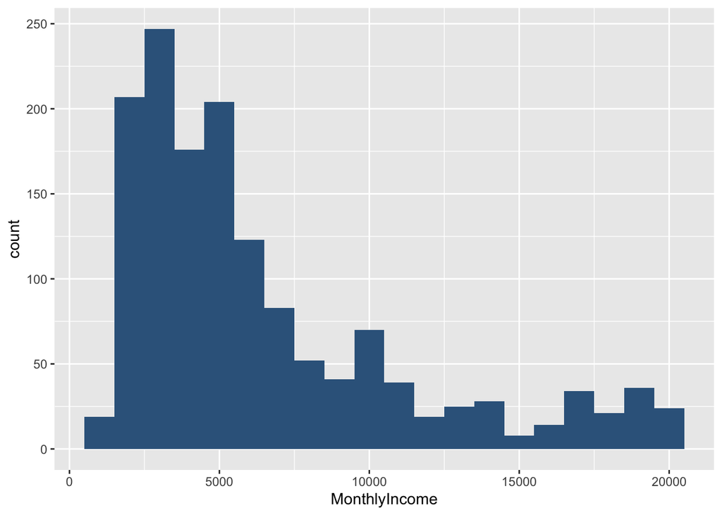

```r
## Create histogram of monthly income width bindwidth of 1,000
gg<-ggplot(at,aes(x=MonthlyIncome))
gg<-gg+geom_histogram(fill = "steelblue4", binwidth = 1000)

## Print plot
gg
```

#### 2) Create a graph that shows the average level of monthly income by field of education.

First, I grouped the `at` dataset by field of education. Then, I summarized the average monthly income in a new dataset, which I named `mi_sum` .

```r
## Group by field of education and summarize mean monthly income
mi_sum<-at%>%
  group_by(EducationField)%>%
  summarize(mi_avg=mean(MonthlyIncome))

## Print new dataset
mi_sum
```

```
## # A tibble: 6 x 2
##   EducationField   mi_avg
##   <chr>             <dbl>
## 1 Human Resources   7241.
## 2 Life Sciences     6463.
## 3 Marketing         7349.
## 4 Medical           6510.
## 5 Other             6072.
## 6 Technical Degree  5758.
```

Then, I displayed the results in a bar plot.

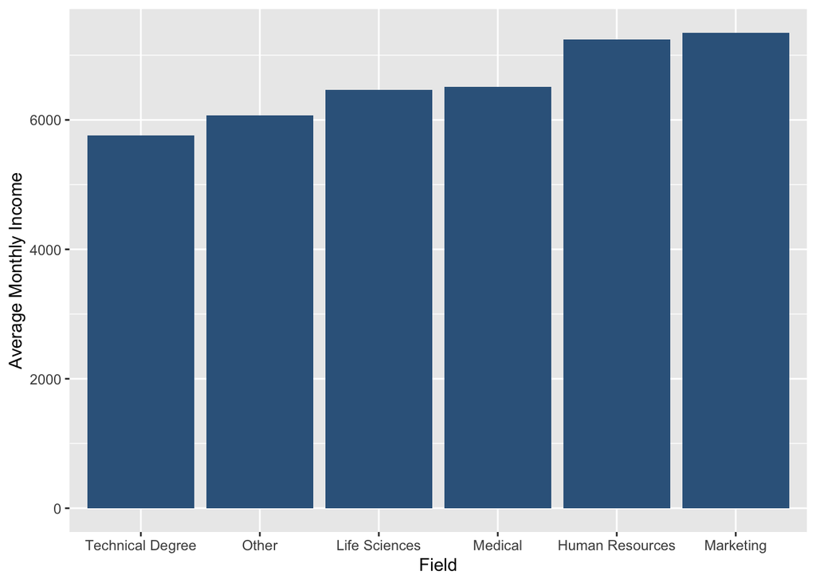

```r
## Create bar plot with mean monthly income as y, education field as x. Order from low to high
gg<-ggplot(mi_sum,aes(x=fct_reorder(EducationField,mi_avg),y=mi_avg))

## Use bar plot geometry, height of bars set by level observed in dataset
gg<-gg+geom_bar(stat="Identity", fill="steelblue4")

## Label axes
gg<-gg+xlab("Field")+ylab("Average Monthly Income")

## Print plot
gg
```

#### 3) Create another graph that shows average level of monthly income by field of education and gender.

First, I summarized monthly income by field of education and gender, in a new dataset, `mi_sum2`.

```r
## Summarize monthly income by field of educcation -and- gender
mi_sum2<-at%>%
  group_by(EducationField,Gender)%>%
  summarize(mi_avg=mean(MonthlyIncome))

## Print the results
mi_sum2
```

```
## # A tibble: 12 x 3
## # Groups:   EducationField [6]
##    EducationField   Gender mi_avg
##    <chr>            <chr>   <dbl>
##  1 Human Resources  Female  9568.
##  2 Human Resources  Male    6262.
##  3 Life Sciences    Female  6433.
##  4 Life Sciences    Male    6483.
##  5 Marketing        Female  7586.
##  6 Marketing        Male    7167.
##  7 Medical          Female  6520.
##  8 Medical          Male    6503.
##  9 Other            Female  6114.
## 10 Other            Male    6048.
## 11 Technical Degree Female  7148.
## 12 Technical Degree Male    4855.
```

Then, I graphed it as a bar plot, using color to represent the results by gender.

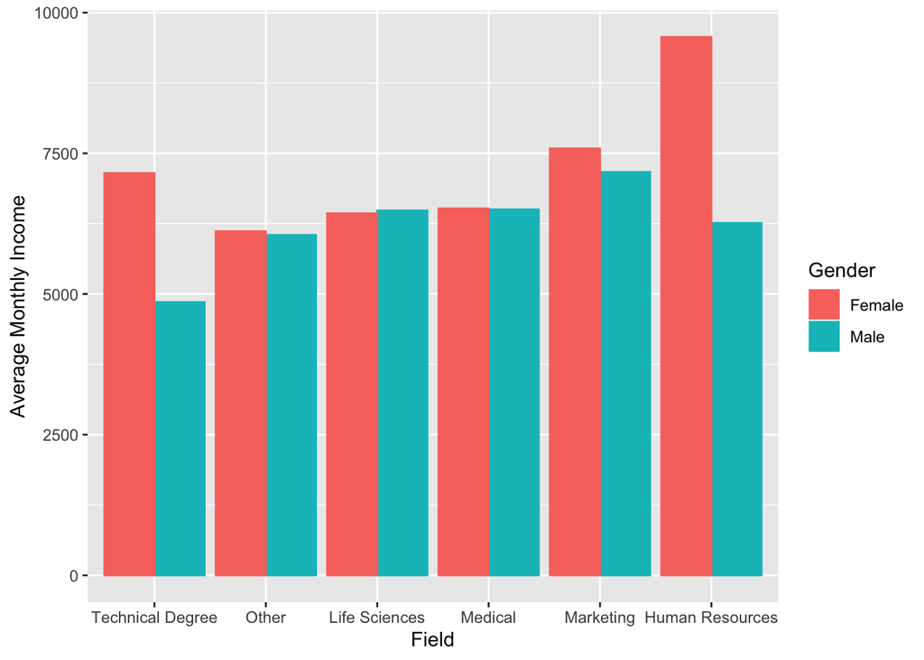

```r
## Plot it using a bar plot
gg<-ggplot(mi_sum2,aes(x=fct_reorder(EducationField,mi_avg),y=mi_avg,color=Gender))
gg<-gg+geom_bar(stat="identity",aes(fill=Gender),position="dodge")
gg<-gg+ylab("Average Monthly Income")+xlab("Field")

## Print plot
gg
```

#### 4) Create a graph that shows average levels of monthly income by field of education, gender and job level (scale of 1-5, highest ranked employees are 5)

I created a new dataset, `mi_sum3` that summarized average levels of monthly income by field of education, gender and job level. I arranged the data by average monthly income, from highest to lowest.

```r
## Summarize monthly income by field of educcation, gender, and job level
mi_sum3<-at%>%
  group_by(EducationField,Gender,JobLevel)%>%
  summarize(mi_avg=mean(MonthlyIncome))%>%
  arrange(-mi_avg)

## Print the results
mi_sum3
```

```
## # A tibble: 58 x 4
## # Groups:   EducationField, Gender [12]
##    EducationField   Gender JobLevel mi_avg
##    <chr>            <chr>     <int>  <dbl>
##  1 Technical Degree Female        5 19744
##  2 Other            Male          5 19443.
##  3 Human Resources  Male          5 19322
##  4 Medical          Male          5 19251.
##  5 Technical Degree Male          5 19232
##  6 Life Sciences    Male          5 19232.
##  7 Life Sciences    Female        5 19143
##  8 Marketing        Female        5 19101.
##  9 Other            Female        5 19094
## 10 Medical          Female        5 19032.
## # … with 48 more rows
```

I then plotted it is a bar graph with a facet wrap according to job level (where highest-ranked employees are represented as a “5”).

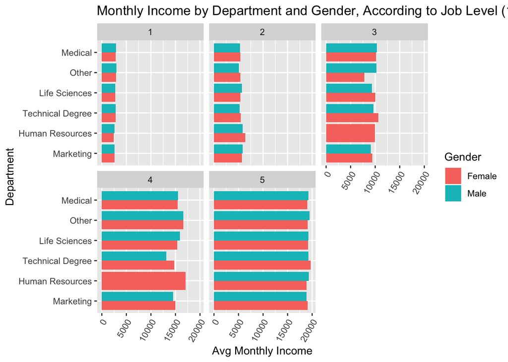

```r
## Plot it using a bar plot
gg<-ggplot(mi_sum3,aes(x=reorder(EducationField,mi_avg),
                      y=mi_avg,
                      fill=Gender))

## Unstack the bar plot
gg<-gg+geom_bar(stat="identity",position="dodge")

## Separate out by job level
gg<-gg+facet_wrap(~JobLevel)

## Flip the coordinates
gg<-gg+coord_flip()

## Label the axes
gg<-gg+ylab("Avg Monthly Income")+xlab("Department")

## Angle the x-axis text
gg<-gg+theme(axis.text.x = element_text(angle = 60, hjust = 1))

## Title the graph
gg<-gg+ggtitle("Monthly Income by Department and Gender, According to Job Level (1-5)")

## Print plot
gg
```

[output not shown]